# Technical note: Amorphous track model with Libamtrack

### Estimating ATM parameters and relative effectiveness

To compute the dosimeter response and relative efficiency we will use the libAmTrack implementation of the compound Poison processes and successive convolutions (CSPP_SC). This calculation model was implemented by Greilich *et all* (Greilich, 2013). The general idea of CSPP_SC for calculating spatial disposition of the local dose distribution is to consider a point P, from which we calculate the cumulative distribution function $F(d)$ for a given macroscopic fluence $\phi$ or macroscopic dose D, and $d(r)$ the microscopic pattern around a track. Considering $r_{max}$ the maximum range of secondary electrons, the point P can only be affected by tracks within a circle of radius $r_{max}$ centered in P. The tracks inside the circle contribute to the local dose d, and the number of tracks is Poisson distributed ($\mu = \phi\cdot \pi r_{max}^2$), and the cumulative single impact distribution is given by
$$\begin{equation}
F_1(d) = 1-\frac{R(d)^2}{r_{max}^2},
\end{equation}$$
where $R(d)$ is the inverse of the radial dose distribution $D(r)$.

For $n$ tracks, the cumulative impact distribution is an n-fold convolution of $F_1$,
$$\begin{equation}
F_n = F_1*...*F_1, \quad \textrm{n times}.
\end{equation}$$
The distribution for a given *d*, with a Poisson distributed *n* is:
$$\begin{equation}
F(d) = e^{-\mu} \sum_{i=0}^\infty \frac{\mu^i}{i!}F_i(d).
\end{equation}$$
The local expected response $\langle s\rangle$ is found from the derivative $f(d)$,
$$\begin{equation}
\langle s\rangle = \int_0^{max(d)}S_X(d)f(d)dd,
\end{equation}$$
where $S_X$ is the local response. CSPP_SC uses successive convolutions to accelerate the calculation of $f(d)$.

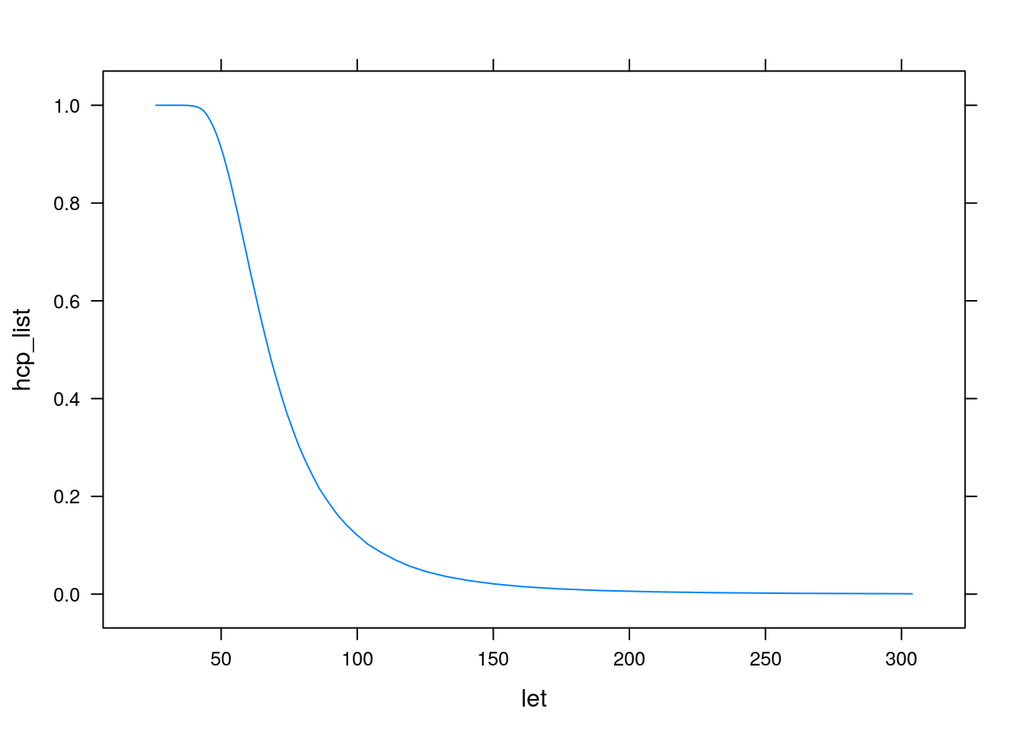

```r
    R           <- 28
    Smax        <- 3.61
    k1          <- Smax * (R / 100)
    k2          <- Smax * (1 - R / 100)


df <- expand.grid(E.MeV.u = seq(.8, 20, length.out=100), #10^seq(0, 3, length.out=500)
                  particle.no = c(1001),
                  material.no = 1,
                  rdd.model = 4,
                  rdd.parameter =  1,
                  gamma.model   = 2,
                  gamma.parameters = 1,
                  er.model = 6,
                  fluence.cm2.or.dose.Gy = c(1e6)
                     )

   df$particle.name <-  "Protons"
    hcp_list =0
    let=0
    for (i in 1:nrow(df)){ # Loop through particles/energies
        result <- AT.run.CPPSC.method(        E.MeV.u          = df$E.MeV.u[i],
                                  particle.no      = df$particle.no[i],
                                  material.no      = df$material.no[i],
                                  fluence.cm2.or.dose.Gy = df$fluence.cm2.or.dose.Gy[i],
                                  rdd.model        = df$rdd.model[i],
                                  rdd.parameters   = c(50e-9, 1e-10),
                                  gamma.model      = df$gamma.parameters[i],
                                  gamma.parameter  = c( k1 = k1, D01 = 2.031*10^3, c1 = 1, m1 = 1,
                                                        k2 = k2, D02 =9.24*10^2, c2 = 2, m2 = 1, 0),
                                  er.model         = df$er.model[i],
                                  write.output     = TRUE,
                                               N2 = 10,
                                               fluence.factor = 1.0,
                                               shrink.tails = TRUE,
                                               shrink.tails.under = 1e-30,
                                               adjust.N2 = TRUE,
                                               lethal.events.mode = FALSE,
                                  stopping.power.source.no = 2)

        hcp_list[i] = result[2]

        let_vals <- AT.dose.weighted.LET.MeV.cm2.g( E.MeV.u       = df$E.MeV.u[i],
                                   particle.no   = c(1001),
                                   fluence.cm2   = df$fluence.cm2.or.dose.Gy[i],
                                   material.no   = 1,                   # water
                                   stopping.power.source.no = 2)

        let[i] = let_vals[1]
    }

    lattice::xyplot(hcp_list ~ let,
                   # Plot
                     df,
                     type      = 'l',
                     auto.key  = TRUE)
```